# Reproducible Research: Peer Assessment 1

Fagner Sutel de Moura

2/11/2018

## Loading and preprocessing the data

- Load the libraries
- Carregamento das bibliotecas

```r
library(ggplot2)
library(dplyr)
library(data.table)
```

- Code for reading in the dataset and/or processing the data
- Codigo para ler os dados e/ou processar as dados

```r
data_na <- read.csv("activity.csv")
head(data_na)
```

```
##   steps       date interval
## 1    NA 2012-10-01        0
## 2    NA 2012-10-01        5
## 3    NA 2012-10-01       10
## 4    NA 2012-10-01       15
## 5    NA 2012-10-01       20
## 6    NA 2012-10-01       25
```

- Remocao dos valores nulos
- Remove NA values

```r
data <- na.omit(data_na)
head(data)
```

```
##     steps       date interval
## 289     0 2012-10-02        0
## 290     0 2012-10-02        5
## 291     0 2012-10-02       10
## 292     0 2012-10-02       15
## 293     0 2012-10-02       20
## 294     0 2012-10-02       25
```

## What is mean total number of steps taken per day?

- Filtro os dados para passos diarios
- Apply the filter of steps taken by day

```r
passos <- data %>%
        group_by(date) %>%
                summarise(steps = sum(steps))
head(passos)
```

```
## # A tibble: 6 x 2
##   date       steps
##   <fct>      <int>
## 1 2012-10-02   126
## 2 2012-10-03 11352
## 3 2012-10-04 12116
## 4 2012-10-05 13294
## 5 2012-10-06 15420
## 6 2012-10-07 11015
```

- Obtemos a media de passos por dia
- obtain the mean of steps by day

```r
media <- mean(passos$steps)
paste("A media foi de: ", media, sep = " " )
```

```
## [1] "A media foi de:  10766.1886792453"
```

```r
paste("The mean is: ", media, sep = " " )
```

```
## [1] "The mean is:  10766.1886792453"
```

```r
mediana <- median(passos$steps)
paste("A mediana foi de: ", mediana, sep = " " )
```

```
## [1] "A mediana foi de:  10765"
```

```r
paste("The median is: ", mediana, sep = " " )
```

```
## [1] "The median is:  10765"
```

- Monto a plotagem dos dados
- Plot the data

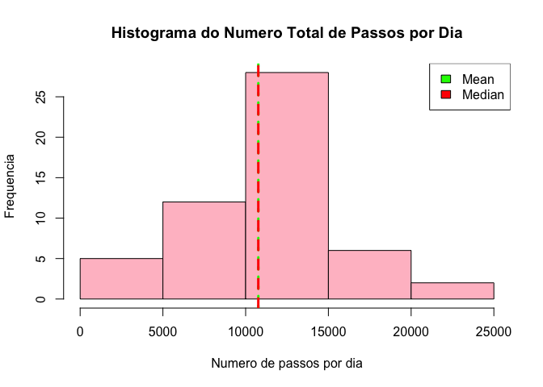

```r
hist(passos$steps, xlab = "Numero de passos por dia", ylab = "Frequencia", main = "Histograma do Numero Total de Passos por Dia", col = "pink")
#abline(v = media,  col="green", lwd=3, lty=3)
abline(v=c(media,mediana), col=c("green", "red"), lty=c(3,2), lwd=c(3, 3))
legend("topright", c("Mean", "Median"), fill=c("Green", "red"))
```

## What is the average daily activity pattern?

- Fazemos um pipeline para obter a media de passadas por intervalos de data
- Make a pu=ipeline to obtain the average deily activity

```r
media_de_passadas <- data %>%
        group_by(interval) %>%
                summarise(steps = mean(steps))
head(media_de_passadas)
```

```
## # A tibble: 6 x 2
##   interval  steps
##      <int>  <dbl>
## 1        0 1.72
## 2        5 0.340
## 3       10 0.132
## 4       15 0.151
## 5       20 0.0755
## 6       25 2.09
```

- Plot the data
- Monto a plotagem dos dados

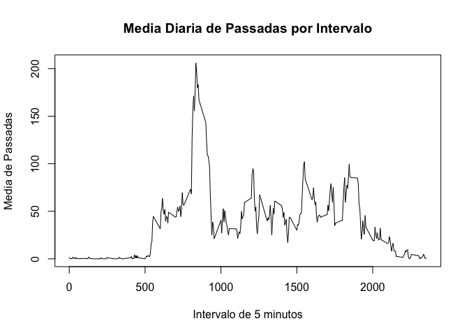

```r
plot(media_de_passadas$interval, media_de_passadas$steps, type="l", xlab="Intervalo de 5 minutos", ylab="Media de Passadas",main="Media Diaria de Passadas por Intervalo")
```

- The maximum number of steps by interval
- O maior numero de passadas por intervalo

```r
maior_intervalo <- media_de_passadas[which.max(media_de_passadas$steps),1]
paste("O Maior numero de passadas ao longo do dia foi: ", maior_intervalo, sep = " ")
```

[output not shown]

```r
paste("The maximum number of steps by interval was: ", maior_intervalo, sep = " ")
```

[output not shown]

## Imputing missing values

- Obtain the number of NAs
- Obtemos o numero de valores nulos

```r
size <- length(which(is.na(data_na$steps)))
paste("Numero de NAs: ", size, sep = " " )
```

```
## [1] "Numero de NAs:  2304"
```

```r
paste("Number of NAs: ", size, sep = " " )
```

```
## [1] "Number of NAs:  2304"
```

- Sunstitui-se os NAs pelo numero medio de passadas no dataset
- Replace NAS with the mean of steps without NAs in this dataset

```r
data_na$steps = ifelse(is.na(data_na$steps), mean(data_na$steps, na.rm = T), data_na$steps)
head(data_na)
```

```
##     steps       date interval
## 1 37.3826 2012-10-01        0
## 2 37.3826 2012-10-01        5
## 3 37.3826 2012-10-01       10
## 4 37.3826 2012-10-01       15
## 5 37.3826 2012-10-01       20
## 6 37.3826 2012-10-01       25
```

- Obtain the number of NAs
- Obtemos o numero de valores nulos

```r
size <- length(which(is.na(data_na$steps)))
paste("Numero de NAs: ", size, sep = " " )
```

```
## [1] "Numero de NAs:  0"
```

```r
paste("Number of NAs: ", size, sep = " " )
```

```
## [1] "Number of NAs:  0"
```

- Utilizo a funcao tapply para obtera soma de passos por data
- Use tapply function to obtain the sum of steps by day

```r
filtro <- tapply(data_na$steps, data_na$date, sum)
head(filtro)
```

```
## 2012-10-01 2012-10-02 2012-10-03 2012-10-04 2012-10-05 2012-10-06
##   10766.19     126.00   11352.00   12116.00   13294.00   15420.00
```

- Converto as datas para milesegundos
- Convert dates to mileseconds format

```r
data_na$date <- as.POSIXct(data_na$date)
```

- Crio a variavel mes e extrai seu valor do atributo date
- Create the mes variable and obtain your value of date atribute

```r
data_na$mes <- as.numeric(format(data_na$date, "%m"))
```

- Media de passos por dia
- Avera of steps taken each day

```r
media_dia <- mean(filtro)
```

- Mediana de passos por dia
- Median of steps taken each day

```r
mediana_dia <- median(filtro)
```

- Crio o histrograma com o numero de passos por dia apos inserir os valores nulos tratados
- Create the histogram of number steps taken each day after treat de minning values

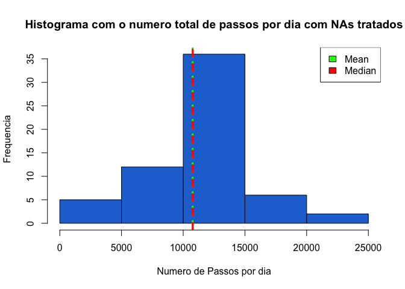

```r
hist(filtro, xlab = "Numero de Passos por dia", ylab = "Frequencia", main = "Histograma com o numero total de passos por dia com NAs tratados", col = "#2073d4")
abline(v=c(media_dia,mediana_dia), col=c("green", "red"), lty=c(3,2), lwd=c(3, 3))
legend("topright", c("Mean", "Median"), fill=c("Green", "red"))
```

## Are there differences in activity patterns between weekdays and weekends?

- Criamos a coluna dia com o dia da semama obtido do atributo date
- Create the dia column with the weekday obtained from de date attibute

```r
data_na$dia <- weekdays(data_na$date)
head(data_na)
```

```
##     steps       date interval mes    dia
## 1 37.3826 2012-10-01        0  10 Monday
## 2 37.3826 2012-10-01        5  10 Monday
## 3 37.3826 2012-10-01       10  10 Monday
## 4 37.3826 2012-10-01       15  10 Monday
## 5 37.3826 2012-10-01       20  10 Monday
## 6 37.3826 2012-10-01       25  10 Monday
```

- Aplicamos o filtro para criar as categorias ‘weekend’ e ‘weekday’
- Apply filter to create the categories ‘weekend’ and ‘weekday’ *My computer is in portuguese PT_BR and the function weekdays can convert the weekdays to [segunda, terca, quarta, quinta…] instead [monday, tuesday, ….]. My option to solve this is include two modes of days to execurrute correct a function to obtain the classes weekend ou weekday

```r
data_na$tipo_dia <- ifelse(data_na$dia == "sabado" | data_na$dia == "domingo" | data_na$dia == "Saturday" | data_na$dia == "Sunday", "Weekend", "Weekday")
head(data_na)
```

```
##     steps       date interval mes    dia tipo_dia
## 1 37.3826 2012-10-01        0  10 Monday  Weekday
## 2 37.3826 2012-10-01        5  10 Monday  Weekday
## 3 37.3826 2012-10-01       10  10 Monday  Weekday
## 4 37.3826 2012-10-01       15  10 Monday  Weekday
## 5 37.3826 2012-10-01       20  10 Monday  Weekday
## 6 37.3826 2012-10-01       25  10 Monday  Weekday
```

- Converter a variavel tipo_dia para um tipo categorico
- Convert tipo_dia to factor variable

```r
data_na$tipo_dia <- as.factor(data_na$tipo_dia)
summary(data_na$tipo_dia)
```

```
## Weekday Weekend
##   12960    4608
```

- Crio o dataframe medias_dias com as medias de passadas aos dias uteis e fins de semana
- Create a dataframe medias_dias with the average of the weekdays and weekend

```r
medias_dias <- data_na %>%
                      group_by(tipo_dia,interval) %>%
                      summarise(steps = mean(steps))
head(medias_dias)
```

```
## # A tibble: 6 x 3
## # Groups:   tipo_dia [1]
##   tipo_dia interval steps
##   <fct>       <int> <dbl>
## 1 Weekday         0  7.01
## 2 Weekday         5  5.38
## 3 Weekday        10  5.14
## 4 Weekday        15  5.16
## 5 Weekday        20  5.07
## 6 Weekday        25  6.30
```

- Plotagem dos dados medios para dias uteis e fins de semana
- Plot data average of weekdays and weekend

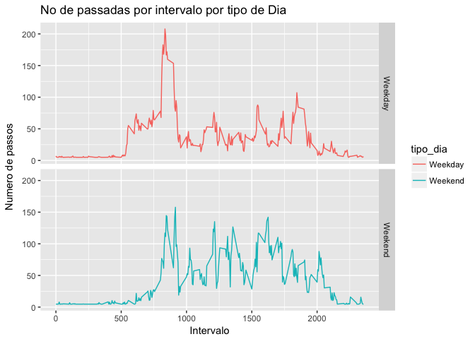

```r
ggplot(data = medias_dias, aes(x = interval, y = steps)) +
  facet_grid(tipo_dia ~ .) +
  geom_line(stat = "identity", aes(colour = tipo_dia)) +
  ggtitle("No de passadas por intervalo por tipo de Dia") +
  labs(x="Intervalo", y=expression("Numero de passos"))
```

## Alternative Mode

- Primeiro criamos dataFrames para dias uteis e fins de semana
- First create a weekdays and weekend dataFrames

```r
weekday_db <- medias_dias[medias_dias$tipo_dia == "Weekday", ]
weekday_db
```

```
## # A tibble: 288 x 3
## # Groups:   tipo_dia [1]
##    tipo_dia interval steps
##    <fct>       <int> <dbl>
##  1 Weekday         0  7.01
##  2 Weekday         5  5.38
##  3 Weekday        10  5.14
##  4 Weekday        15  5.16
##  5 Weekday        20  5.07
##  6 Weekday        25  6.30
##  7 Weekday        30  5.61
##  8 Weekday        35  6.01
##  9 Weekday        40  4.98
## 10 Weekday        45  6.58
## # ... with 278 more rows
```

```r
weekend_db <- medias_dias[medias_dias$tipo_dia == "Weekend", ]
weekend_db
```

```
## # A tibble: 288 x 3
## # Groups:   tipo_dia [1]
##    tipo_dia interval steps
##    <fct>       <int> <dbl>
##  1 Weekend         0  4.67
##  2 Weekend         5  4.67
##  3 Weekend        10  4.67
##  4 Weekend        15  4.67
##  5 Weekend        20  4.67
##  6 Weekend        25  7.92
##  7 Weekend        30  4.67
##  8 Weekend        35  4.67
##  9 Weekend        40  4.67
## 10 Weekend        45  5.05
## # ... with 278 more rows
```

- Criamos as plotagens dos dois dataFrames
- Create the plots of dataFrames

```r
data_weekdays<- ggplot(weekday_db) +
        geom_line(aes(x = interval, y = steps), colour = "red", linetype = "dashed") +
    xlab("Intervalos de Dias Uteis") +
    ylab("Passsos")

data_weekends <- ggplot(weekend_db) +
        geom_line(aes(x = interval, y = steps), colour = "blue", linetype = "dotted") +
  xlab("Intervalos de Fins de Semana") +
  ylab("Passsos")
```

- Instalamos e Carregamos a biblioteca para criar grid de plotagens
- Install and load the library to create a plot grid

```r
#install.packages('gridExtra')
library(gridExtra)
```

- Exibimos o grid criado
- Displays a created grid

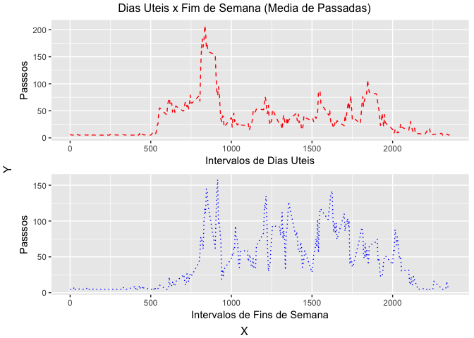

```r
grid.arrange(data_weekdays,data_weekends,  ncol=1, top = "Dias Uteis x Fim de Semana (Media de Passadas)", left = "Y", bottom = "X")
```